# Question

Un experimento consiste en medir el alcance horizontal de un proyectil en función del ángulo con el que se lanza (respecto a la horizontal). En la gráfica se registran los resultados de 94 lanzamientos realizados con la misma velocidad inicial.

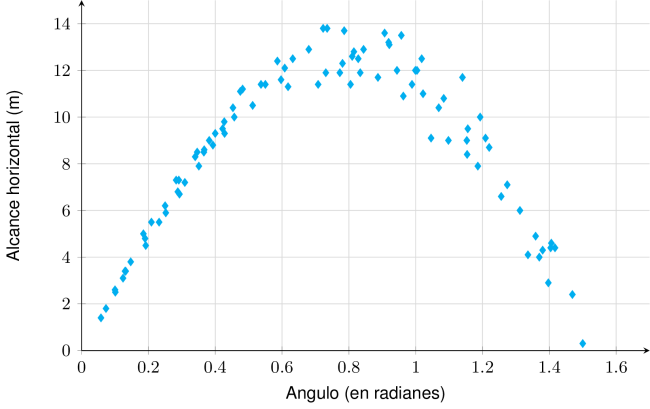

El comportamiento del alcance respecto al ángulo es

## Answerlist

- lineal y mas variable cuanto mayor sea la inclinacion inicial.
- lineal y mas variable cuanto mayor sea el alcance.
- no lineal y mas variable cuanto mayor sea la inclinacion inicial.
- no lineal y mas variable cuanto mayor sea el alcance.

# Solution

Para analizar el comportamiento del alcance respecto al ángulo, debemos observar dos aspectos clave en la gráfica de dispersión:

**1. Tipo de relacion (lineal vs no lineal):**

La relacion entre el ángulo y el alcance sigue la ecuación del movimiento de proyectiles:

$$R = \frac{v_0^2
\sin(2\theta)}{g}$$

Esta es una función senoidal, por lo tanto **no lineal**. En la gráfica se observa claramente una forma parabólica con un máximo aproximadamente en $\theta \approx 0.78$ radianes ($\approx 45°$).

**2. Patrón de dispersión:**

Observando la gráfica:

- En ángulos bajos (cercanos a 0 radianes): los puntos están más concentrados
- En ángulos altos (cercanos a 1.5 radianes): los puntos muestran mayor variabilidad

Esto indica que **la dispersión es proporcional a la inclinacion inicial**, no a el alcance. Físicamente, esto puede explicarse porque los errores en la medición del ángulo se amplifican en configuraciones de lanzamiento con mayor inclinación.

**Conclusión:**

El comportamiento es **no lineal** (forma parabólica) y **mas variable cuanto mayor sea la inclinacion inicial** (mayor variabilidad en ángulos altos).

## Answerlist

- **Falso**. La relación no es lineal (es no lineal) y aunque la dispersión sí depende de la inclinacion inicial, el tipo de relación es incorrecto.
- **Falso**. La relación NO es lineal y la dispersión NO aumenta con el alcance sino con la inclinacion inicial.
- **Verdadero**. La relación es no lineal (forma parabólica) y la dispersión aumenta proporcionalmente a la inclinacion inicial.
- **Falso**. Si bien la relación es no lineal, la dispersión NO aumenta con el alcance sino con la inclinacion inicial.

# Meta-information

exname: dispersion_alcance_proyectil_aleatorio_interpretacion_representacion_n2_v1 extype: schoice exsolution: 0010 exshuffle: TRUE exsection: Estadistica/Graficas de Dispersion